# Yulu_Business_Case

## Description:

Yulu is India’s leading micro-mobility service provider, which offers unique vehicles for the daily commute. Starting off as a mission to eliminate traffic congestion in India, Yulu provides the safest commute solution through a user-friendly mobile app to enable shared, solo and sustainable commuting.

Yulu zones are located at all the appropriate locations (including metro stations, bus stands, office spaces, residential areas, corporate offices, etc) to make those first and last miles smooth, affordable, and convenient!

Yulu has recently suffered considerable dips in its revenues. They have contracted a consulting company to understand the factors on which the demand for these shared electric cycles depends. Specifically, they want to understand the factors affecting the demand for these shared electric cycles in the Indian market.

## Column Profiling:

datetime: datetime

season: season (1: spring, 2: summer, 3: fall, 4: winter)

holiday: whether day is a holiday or not (extracted from http://dchr.dc.gov/page/holiday-schedule)

workingday: if day is neither weekend nor holiday is 1, otherwise is 0.

weather: 1: Clear, Few clouds, partly cloudy, partly cloudy 2: Mist + Cloudy, Mist + Broken clouds, Mist + Few clouds, Mist 3: Light Snow, Light Rain + Thunderstorm + Scattered clouds, Light Rain + Scattered clouds 4: Heavy Rain + Ice Pallets + Thunderstorm + Mist, Snow + Fog

temp: temperature in Celsius

atemp: feeling temperature in Celsius

humidity: humidity

windspeed: wind speed

casual: count of casual users

registered: count of registered users

count: count of total rental bikes including both casual and registered

## Problem Statement

Between January 2011 and December 2012, Yulu suffered from a significant drop in its revenue due to reduced demand in electric cycles. This project will analyze the demand patterns underlying the variables which are Season, weather and type of day. The scope of this project is particularly the urban usage in the India Market.The objective of this project is to determine and understand the reasons behind the loss. The recommendations and insights will be generated that will increase the total amount of users by 15%.

## Analytical Questions

1. Which Season appears to generate lowest revenue and In which Quarter does the obtained revenue is very less ?
2. Is weather causing any considerable impact on the revenue ?
3. Does day of the month and time of the day have any effect on bike user behaviour?
4. Is there any hidden relation between weather, season and Quarter ?
5. What temperature range has least amount of active users?
6. Is humidity a considerable factor in less usage of yulu cycles ?

## Final Recommendations:

1. Increase the Cycle availability during favourable weather conditions and peak seasons.
2. Optimize operational Planning according to seasonal demand fluctuations.
3. Implement marketing campaigns during low demand seasons.
4. Sever weather, humidity and seasonal conditions are to be monitored as they have negative impact on the business.
5. Use seasonal trends for inventory management and maintainance scheduling.

## Exploratory Data Analysis

```python
import numpy as np
import pandas as pd
import matplotlib.pyplot as plt
import seaborn as sns

from scipy.stats import ttest_ind, f_oneway, chi2_contingency, shapiro, levene
```

```python
data = pd.read_csv("bike_sharing.txt")
```

```python
data.shape
```

```
(10886, 12)
```

```python
data.ndim
```

```
2
```

```python
data.head()
```

|  | datetime | season | holiday | workingday | weather | temp | atemp | humidity | windspeed | casual | registered | count |
| --- | --- | --- | --- | --- | --- | --- | --- | --- | --- | --- | --- | --- |
| 0 | 2011-01-01 00:00:00 | 1 | 0 | 0 | 1 | 9.84 | 14.395 | 81 | 0.0 | 3 | 13 | 16 |
| 1 | 2011-01-01 01:00:00 | 1 | 0 | 0 | 1 | 9.02 | 13.635 | 80 | 0.0 | 8 | 32 | 40 |
| 2 | 2011-01-01 02:00:00 | 1 | 0 | 0 | 1 | 9.02 | 13.635 | 80 | 0.0 | 5 | 27 | 32 |
| 3 | 2011-01-01 03:00:00 | 1 | 0 | 0 | 1 | 9.84 | 14.395 | 75 | 0.0 | 3 | 10 | 13 |
| 4 | 2011-01-01 04:00:00 | 1 | 0 | 0 | 1 | 9.84 | 14.395 | 75 | 0.0 | 0 | 1 | 1 |

```python
# Checking the data types and null values in the data
data.info()
```

```
<class 'pandas.core.frame.DataFrame'>
RangeIndex: 10886 entries, 0 to 10885
Data columns (total 12 columns):
 #   Column      Non-Null Count  Dtype
---  ------      --------------  -----
 0   datetime    10886 non-null  object
 1   season      10886 non-null  int64
 2   holiday     10886 non-null  int64
 3   workingday  10886 non-null  int64
 4   weather     10886 non-null  int64
 5   temp        10886 non-null  float64
 6   atemp       10886 non-null  float64
 7   humidity    10886 non-null  int64
 8   windspeed   10886 non-null  float64
 9   casual      10886 non-null  int64
 10  registered  10886 non-null  int64
 11  count       10886 non-null  int64
dtypes: float64(3), int64(8), object(1)
memory usage: 1020.7+ KB
```

#### There are no null values but the datatypes are not entirely correct.

```python
data['datetime'] = pd.to_datetime(data['datetime'])
data['season'] = data['season'].astype('category')
data['holiday'] = data['holiday'].astype('category')
data['workingday'] = data['workingday'].astype('category')
data['weather'] = data['weather'].astype('category')
```

```python
data.info()
```

```
<class 'pandas.core.frame.DataFrame'>
RangeIndex: 10886 entries, 0 to 10885
Data columns (total 12 columns):
 #   Column      Non-Null Count  Dtype
---  ------      --------------  -----
 0   datetime    10886 non-null  datetime64[ns]
 1   season      10886 non-null  category
 2   holiday     10886 non-null  category
 3   workingday  10886 non-null  category
 4   weather     10886 non-null  category
 5   temp        10886 non-null  float64
 6   atemp       10886 non-null  float64
 7   humidity    10886 non-null  int64
 8   windspeed   10886 non-null  float64
 9   casual      10886 non-null  int64
 10  registered  10886 non-null  int64
 11  count       10886 non-null  int64
dtypes: category(4), datetime64[ns](1), float64(3), int64(4)
memory usage: 723.7 KB
```

```python
data.describe()
```

|  | datetime | temp | atemp | humidity | windspeed | casual | registered | count |
| --- | --- | --- | --- | --- | --- | --- | --- | --- |
| count | 10886 | 10886.00000 | 10886.000000 | 10886.000000 | 10886.000000 | 10886.000000 | 10886.000000 | 10886.000000 |
| mean | 2011-12-27 05:56:22.399411968 | 20.23086 | 23.655084 | 61.886460 | 12.799395 | 36.021955 | 155.552177 | 191.574132 |
| min | 2011-01-01 00:00:00 | 0.82000 | 0.760000 | 0.000000 | 0.000000 | 0.000000 | 0.000000 | 1.000000 |
| 25% | 2011-07-02 07:15:00 | 13.94000 | 16.665000 | 47.000000 | 7.001500 | 4.000000 | 36.000000 | 42.000000 |
| 50% | 2012-01-01 20:30:00 | 20.50000 | 24.240000 | 62.000000 | 12.998000 | 17.000000 | 118.000000 | 145.000000 |
| 75% | 2012-07-01 12:45:00 | 26.24000 | 31.060000 | 77.000000 | 16.997900 | 49.000000 | 222.000000 | 284.000000 |
| max | 2012-12-19 23:00:00 | 41.00000 | 45.455000 | 100.000000 | 56.996900 | 367.000000 | 886.000000 | 977.000000 |
| std | NaN | 7.79159 | 8.474601 | 19.245033 | 8.164537 | 49.960477 | 151.039033 | 181.144454 |

```python
# Duplicates Check
data.duplicated().sum()
```

```
np.int64(0)
```

#### There are no duplicate rows present in the dataset.

```python
# Checking For Outliers

# Numerical Columns
num_col = data.select_dtypes(include=['int64', 'float64'])

# Categorical Columns
cat_col = data.select_dtypes(exclude=['int64', 'float64', 'datetime'])
```

```python
cat_col
```

|  | season | holiday | workingday | weather |
| --- | --- | --- | --- | --- |
| 0 | 1 | 0 | 0 | 1 |
| 1 | 1 | 0 | 0 | 1 |
| 2 | 1 | 0 | 0 | 1 |
| 3 | 1 | 0 | 0 | 1 |
| 4 | 1 | 0 | 0 | 1 |
| ... | ... | ... | ... | ... |
| 10881 | 4 | 0 | 1 | 1 |
| 10882 | 4 | 0 | 1 | 1 |
| 10883 | 4 | 0 | 1 | 1 |
| 10884 | 4 | 0 | 1 | 1 |
| 10885 | 4 | 0 | 1 | 1 |

10886 rows × 4 columns

## Univariate Analysis

#### Numerical Columns

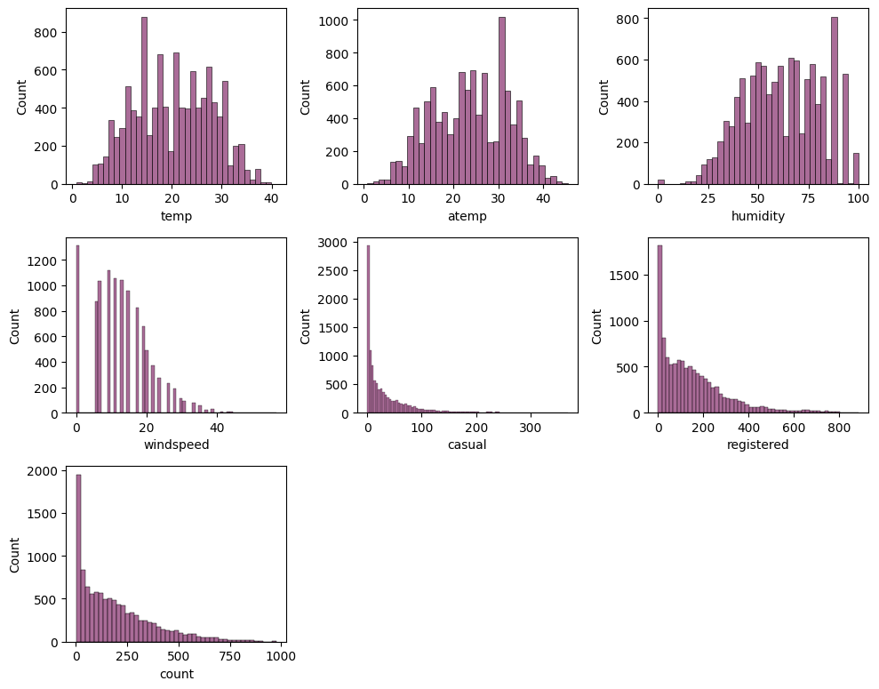

```python
# Plotting Histograms to understand the distribution
plt.figure(figsize=(10,10))

for i, col in enumerate(num_col):
  plt.subplot(4, 3, i+1)
  sns.histplot(data=data, x=col, color='#8E3B76')
  plt.xlabel(col)

plt.tight_layout()
plt.show()
```

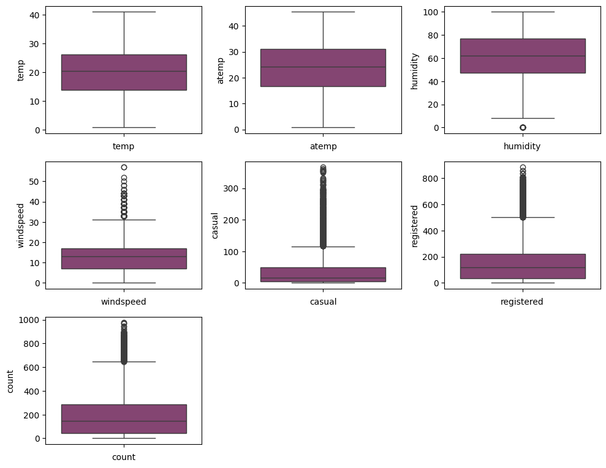

```python
# Plotting Box Plot to determine the presence of Outliers
plt.figure(figsize=(10,10))

for i, col in enumerate(num_col):
  plt.subplot(4, 3, i+1)
  sns.boxplot(data=data, y=col, color='#8E3B76')
  plt.xlabel(col)

plt.tight_layout()
plt.show()
```

#### We can understand that there are some outliers present in the data for the columns: Windspeed, Casual Users, Registered Users and Total Count.

#### General Assumptions -->

1. Very High Windspeeds may increase the risk in using the electric Cycles. So this can be a reason behind the less revenue generation period.
2. Casual user count and Registered User count have outliers, which can mean that during pleasant seasons and days, many users preferred to commute by electric cycles. But Most of the data has low number of casual Users around 15-20.
3. Total users is a sum of Casual User count and Registered User Count, so it increases naturally. The number of registered Users is generally high, And on some days it very high than usual.

#### Categorical Columns

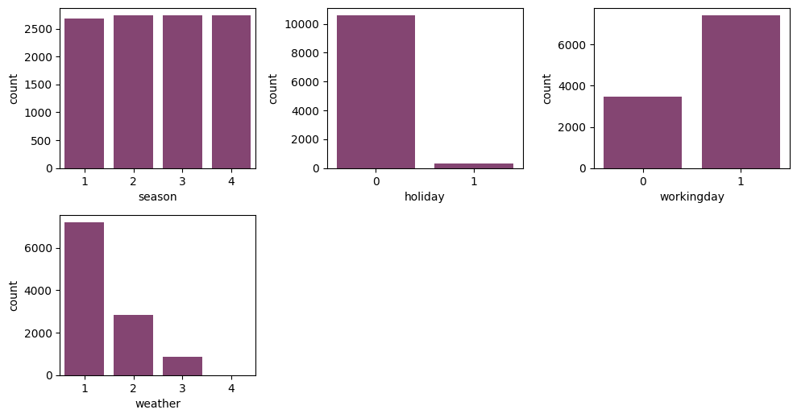

```python
# Plotting barplots for Categorical data

plt.figure(figsize=(10,10))

for i, col in enumerate(cat_col):
  plt.subplot(4,3,i+1)
  sns.countplot(data=data, x=col, color='#8E3B76')
  plt.xlabel(col)

plt.tight_layout()
plt.show()
```

## Bivariate Analysis

#### Numerical Vs Numerical

```python
num_col
```

|  | temp | atemp | humidity | windspeed | casual | registered | count |
| --- | --- | --- | --- | --- | --- | --- | --- |
| 0 | 9.84 | 14.395 | 81 | 0.0000 | 3 | 13 | 16 |
| 1 | 9.02 | 13.635 | 80 | 0.0000 | 8 | 32 | 40 |
| 2 | 9.02 | 13.635 | 80 | 0.0000 | 5 | 27 | 32 |
| 3 | 9.84 | 14.395 | 75 | 0.0000 | 3 | 10 | 13 |
| 4 | 9.84 | 14.395 | 75 | 0.0000 | 0 | 1 | 1 |
| ... | ... | ... | ... | ... | ... | ... | ... |
| 10881 | 15.58 | 19.695 | 50 | 26.0027 | 7 | 329 | 336 |
| 10882 | 14.76 | 17.425 | 57 | 15.0013 | 10 | 231 | 241 |
| 10883 | 13.94 | 15.910 | 61 | 15.0013 | 4 | 164 | 168 |
| 10884 | 13.94 | 17.425 | 61 | 6.0032 | 12 | 117 | 129 |
| 10885 | 13.12 | 16.665 | 66 | 8.9981 | 4 | 84 | 88 |

10886 rows × 7 columns

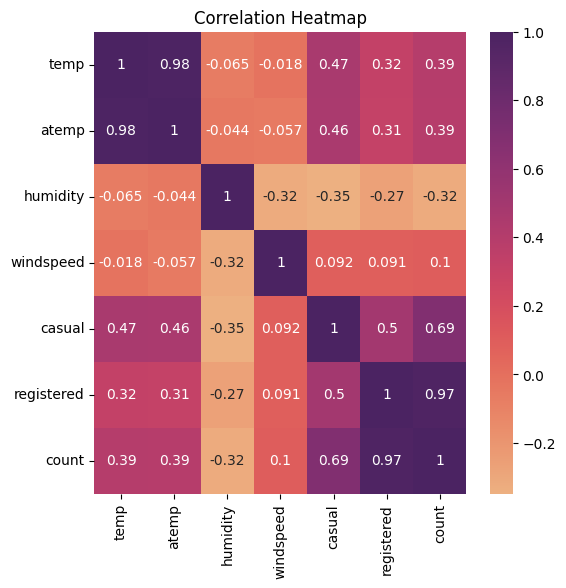

```python
# Plotting Heatmap for Better Understanding
plt.figure(figsize=(6,6))
sns.heatmap(num_col.corr(), annot=True, cmap='flare')
plt.title('Correlation Heatmap')
plt.show()
```

### Insights:

#### Categorical Vs Numerical

```python
data.head(10)
```

|  | datetime | season | holiday | workingday | weather | temp | atemp | humidity | windspeed | casual | registered | count |
| --- | --- | --- | --- | --- | --- | --- | --- | --- | --- | --- | --- | --- |
| 0 | 2011-01-01 00:00:00 | 1 | 0 | 0 | 1 | 9.84 | 14.395 | 81 | 0.0000 | 3 | 13 | 16 |
| 1 | 2011-01-01 01:00:00 | 1 | 0 | 0 | 1 | 9.02 | 13.635 | 80 | 0.0000 | 8 | 32 | 40 |
| 2 | 2011-01-01 02:00:00 | 1 | 0 | 0 | 1 | 9.02 | 13.635 | 80 | 0.0000 | 5 | 27 | 32 |
| 3 | 2011-01-01 03:00:00 | 1 | 0 | 0 | 1 | 9.84 | 14.395 | 75 | 0.0000 | 3 | 10 | 13 |
| 4 | 2011-01-01 04:00:00 | 1 | 0 | 0 | 1 | 9.84 | 14.395 | 75 | 0.0000 | 0 | 1 | 1 |
| 5 | 2011-01-01 05:00:00 | 1 | 0 | 0 | 2 | 9.84 | 12.880 | 75 | 6.0032 | 0 | 1 | 1 |
| 6 | 2011-01-01 06:00:00 | 1 | 0 | 0 | 1 | 9.02 | 13.635 | 80 | 0.0000 | 2 | 0 | 2 |
| 7 | 2011-01-01 07:00:00 | 1 | 0 | 0 | 1 | 8.20 | 12.880 | 86 | 0.0000 | 1 | 2 | 3 |
| 8 | 2011-01-01 08:00:00 | 1 | 0 | 0 | 1 | 9.84 | 14.395 | 75 | 0.0000 | 1 | 7 | 8 |
| 9 | 2011-01-01 09:00:00 | 1 | 0 | 0 | 1 | 13.12 | 17.425 | 76 | 0.0000 | 8 | 6 | 14 |

```python
# Creating Potential features using Feature Engineering
data['month'] = data['datetime'].dt.month
data['date'] = data['datetime'].dt.day
data['hour'] = data['datetime'].dt.hour
data['year'] = data['datetime'].dt.year
data['dayofweek'] = data['datetime'].dt.day_name()
```

```python
data.head()
```

|  | datetime | season | holiday | workingday | weather | temp | atemp | humidity | windspeed | casual | registered | count | month | date | hour | year | dayofweek |
| --- | --- | --- | --- | --- | --- | --- | --- | --- | --- | --- | --- | --- | --- | --- | --- | --- | --- |
| 0 | 2011-01-01 00:00:00 | 1 | 0 | 0 | 1 | 9.84 | 14.395 | 81 | 0.0 | 3 | 13 | 16 | 1 | 1 | 0 | 2011 | Saturday |
| 1 | 2011-01-01 01:00:00 | 1 | 0 | 0 | 1 | 9.02 | 13.635 | 80 | 0.0 | 8 | 32 | 40 | 1 | 1 | 1 | 2011 | Saturday |
| 2 | 2011-01-01 02:00:00 | 1 | 0 | 0 | 1 | 9.02 | 13.635 | 80 | 0.0 | 5 | 27 | 32 | 1 | 1 | 2 | 2011 | Saturday |
| 3 | 2011-01-01 03:00:00 | 1 | 0 | 0 | 1 | 9.84 | 14.395 | 75 | 0.0 | 3 | 10 | 13 | 1 | 1 | 3 | 2011 | Saturday |
| 4 | 2011-01-01 04:00:00 | 1 | 0 | 0 | 1 | 9.84 | 14.395 | 75 | 0.0 | 0 | 1 | 1 | 1 | 1 | 4 | 2011 | Saturday |

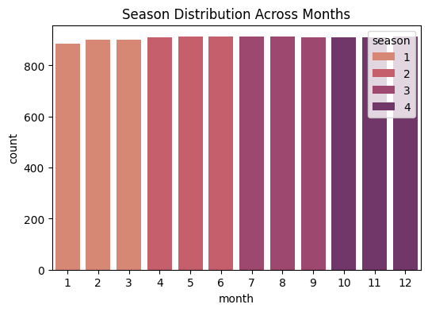

```python
# Which season in Which month ??

plt.figure(figsize=(6,4))

sns.countplot(data=data, x='month', hue='season', palette='flare')

plt.title("Season Distribution Across Months")
plt.show()
```

#### Q1. Which Season appears to generate lowest revenue and In which Quarter does the obtained revenue is very less ?

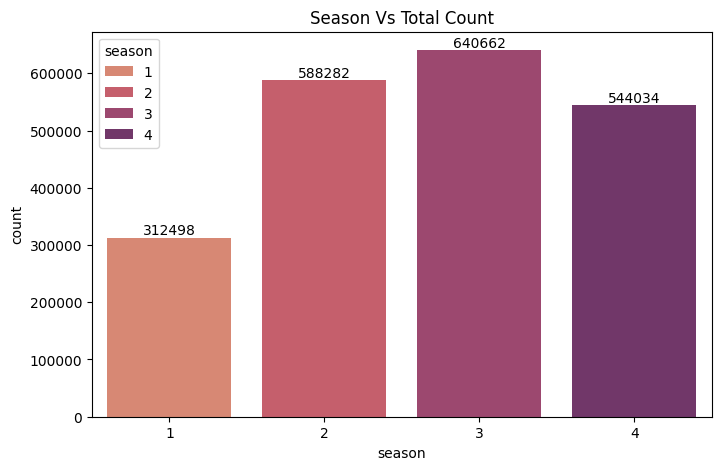

```python
# Season Vs Total Count ( Quarter Analysis )
plt.figure(figsize=(8,5))

season_data = data.groupby('season')['count'].sum().reset_index()

ax = sns.barplot(data=season_data, x='season', y='count', hue='season', palette='flare', errorbar = None)

for container in ax.containers:
  ax.bar_label(container, fmt="%.0f")

plt.title("Season Vs Total Count")
plt.show()
```

#### Seasonal Trend

1. We can clearly see that starting low the Bike rental demand increases gradually from January to June:, With June recording the highest average rentals.
2. Rental Activity remains high between June and September before declining steadily post october.
3. This trend indicates that seasonal conditions have strong influence on the bike rental behaviour.

This plot backs the fact that **People tend to book more rides around summer and fall and prefer to choose safer options on rest of the seasons which is the 1st and 4th Quater.**

#### Q2. Is weather causing any considerable impact on the revenue ?

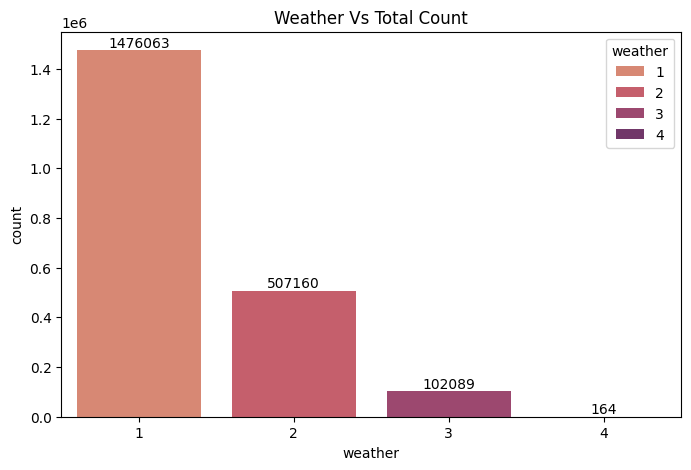

```python
# Weather Vs Total Count
plt.figure(figsize=(8,5))

weather_data = data.groupby('weather')['count'].sum().reset_index()

ax = sns.barplot(data=weather_data, x='weather', y='count', hue='weather', palette='flare', errorbar = None)

for container in ax.containers:
  ax.bar_label(container, fmt="%.0f")

plt.title("Weather Vs Total Count")
plt.show()
```

#### We can clear see how weather is effecting the overall usage of the electric cycles:

1. During Clear, less cloudy days the bike rentals are high in number which makes sense as it is normal human behaviour.
2. The least average number of bike rentals is during light rains and snow and post that. The reason behind this obvious. As the weather becomes more unfavourable the number of bike rentals reduces significantly.

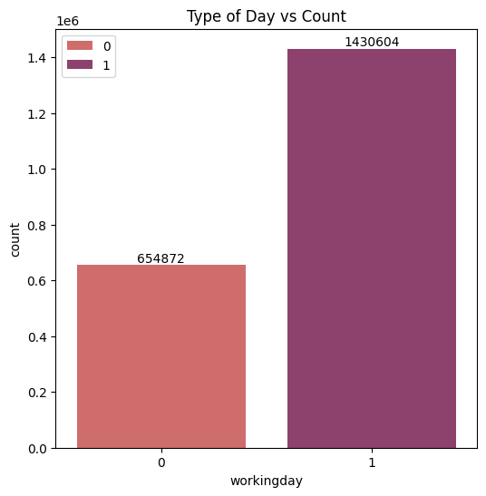

```python
# Working Day Vs Total Count
plt.figure(figsize=(6,6))

day_data = data.groupby('workingday')['count'].sum().reset_index()

ax = sns.barplot(data=day_data, x='workingday', y='count', hue='workingday', palette='flare', errorbar = None)

for container in ax.containers:
  ax.bar_label(container, fmt="%.0f")

plt.legend()
plt.title("Type of Day vs Count")
plt.show()
```

#### The number of bike rentals on working days is twice that of non working days as it is obvious that more people commute on working days than normal days.

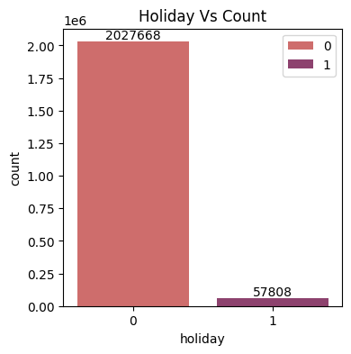

```python
# Holiday Vs Total Count
plt.figure(figsize=(4,4))

holiday_data = data.groupby('holiday')['count'].sum().reset_index()

ax = sns.barplot(data=holiday_data, x='holiday', y="count",hue='holiday', palette='flare', errorbar = None)

for container in ax.containers:
  ax.bar_label(container, fmt="%.0f")

plt.legend()
plt.title("Holiday Vs Count")
plt.show()
```

#### Insights

1. Total bike rentals on non-holidays are significantly higher than on holidays, indicating that bike usage is primarily concentrated on regular working or normal days.
2. Holiday rentals contribute only a very small proportion of the overall rental demand, suggesting reduced commuting or outdoor activity during holidays.
3. The large difference between holiday and non-holiday rental counts indicates that holidays may negatively impact overall bike rental business performance.

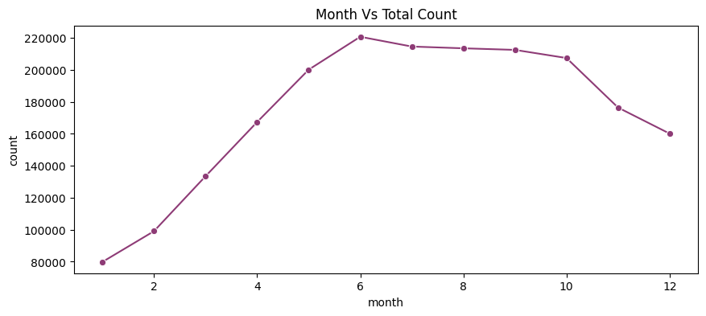

```python
# Month Vs Total Count

plt.figure(figsize=(10,4))

monthly_data = data.groupby('month')['count'].sum().reset_index()

ax = sns.lineplot(
    data=monthly_data,
    x='month',
    y='count',
    marker='o',
    color='#8E3B76'
)



plt.title("Month Vs Total Count")
plt.show()
```

#### Insights:

Using this graph we can confirm our previous insight that from January to June which is usually the period of spring and summer, the number of bike rentals are increasing gradually. After that as the weather becomes unfavourable, the number decreasing with time.

#### Q3. Does day of the month and time of the day have any effect on bike user behaviour?

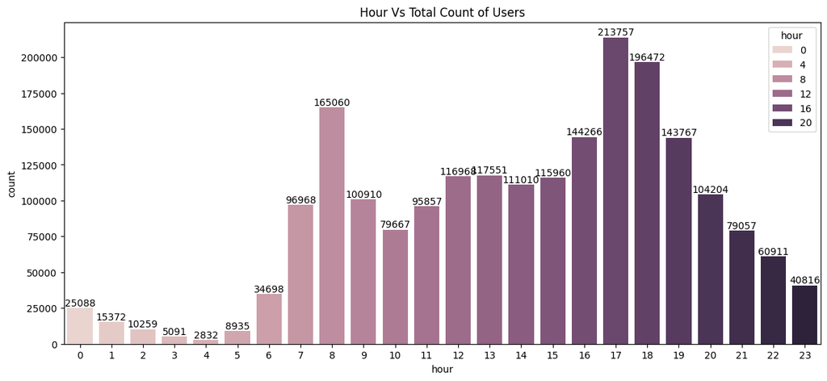

```python
# Hour Vs Total Count

plt.figure(figsize=(14,6))

hourly_data = data.groupby('hour')['count'].sum().reset_index()

ax = sns.barplot(data=hourly_data, x='hour', y='count', hue='hour', errorbar = None)

for container in ax.containers:
  ax.bar_label(container, fmt='%.0f')

plt.title("Hour Vs Total Count of Users")
plt.show()
```

#### Insights:

1. During the early morning and late night, the number of bike rentals are very low. As at that moment, majority of people tend to stay at home and be confortable.
2. The peak is at 8am, where people are actually leaving for schools and offices and rest things, and also at 5pm where people are returning to their homes as the day come to an end. But the people using the bikes while returning are more than the people using bikes in the morning. Maybe they dont prefer cardio while going to their destinations.
3. Now around 9am - 4pm, the bikes are being used in good numbers, but during this period we can work on increasing the usage numbers.

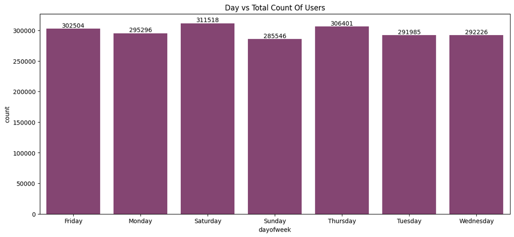

```python
# Day vs Total Count

plt.figure(figsize=(14,6))

daily_data = data.groupby('dayofweek')['count'].sum().reset_index()

ax = sns.barplot(data=daily_data, x='dayofweek', y='count', color='#8E3B76', errorbar = None)

for container in ax.containers:
  ax.bar_label(container, fmt="%.0f")

plt.title("Day vs Total Count Of Users")
plt.show()
```

#### Insights:

1. Bike rentals are relatively consistent throughout the week, indicating stable user demand across all days.
2. Saturday recorded the highest total rentals, suggesting increased bike usage during weekends for leisure or recreational activities.
3. Sunday showed the lowest rental count, while weekdays maintained moderate and comparable rental demand, likely driven by regular commuting patterns.

#### Q4. Is there any hidden relation between weather, season and Quarter ?

Ans:

#### Q5. What temperature range has least amount of active users?

```python
# For this we need to categorize the Temperature Column.

bins = [0, 10, 20, 30, 40, 50]

labels = ['Very Cold', 'Cold', 'Moderate', 'Warm', 'Hot']

data['temp_category'] = pd.cut(
    data['temp'],
    bins=bins,
    labels=labels
)
```

```python
data.head()
```

|  | datetime | season | holiday | workingday | weather | temp | atemp | humidity | windspeed | casual | registered | count | month | date | hour | year | dayofweek | temp_category |
| --- | --- | --- | --- | --- | --- | --- | --- | --- | --- | --- | --- | --- | --- | --- | --- | --- | --- | --- |
| 0 | 2011-01-01 00:00:00 | 1 | 0 | 0 | 1 | 9.84 | 14.395 | 81 | 0.0 | 3 | 13 | 16 | 1 | 1 | 0 | 2011 | Saturday | Very Cold |
| 1 | 2011-01-01 01:00:00 | 1 | 0 | 0 | 1 | 9.02 | 13.635 | 80 | 0.0 | 8 | 32 | 40 | 1 | 1 | 1 | 2011 | Saturday | Very Cold |
| 2 | 2011-01-01 02:00:00 | 1 | 0 | 0 | 1 | 9.02 | 13.635 | 80 | 0.0 | 5 | 27 | 32 | 1 | 1 | 2 | 2011 | Saturday | Very Cold |
| 3 | 2011-01-01 03:00:00 | 1 | 0 | 0 | 1 | 9.84 | 14.395 | 75 | 0.0 | 3 | 10 | 13 | 1 | 1 | 3 | 2011 | Saturday | Very Cold |
| 4 | 2011-01-01 04:00:00 | 1 | 0 | 0 | 1 | 9.84 | 14.395 | 75 | 0.0 | 0 | 1 | 1 | 1 | 1 | 4 | 2011 | Saturday | Very Cold |

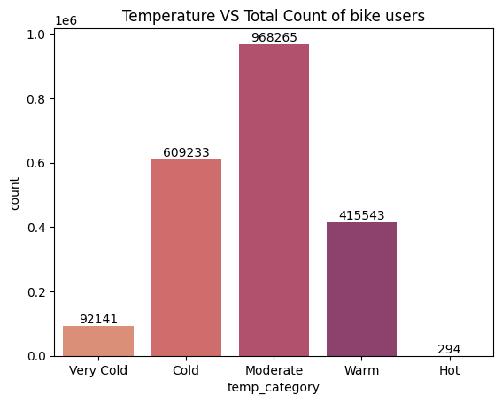

```python
# Plotting the temperature columns against total count of bike rentals.

temperature_data = data.groupby('temp_category')['count'].sum().reset_index()

ax = sns.barplot(data=temperature_data, x='temp_category', y='count', hue='temp_category', palette='flare', errorbar= None)

for container in ax.containers:
  ax.bar_label(container, fmt='%.0f')

plt.title("Temperature VS Total Count of bike users")
plt.show()
```

#### Q6. Is humidity a considerable factor in less usage of yulu cycles ?

```python
bins = [0, 20, 40, 60, 80, 100]

labels = [
    'Very Low',
    'Low',
    'Moderate',
    'High',
    'Very High'
]

data['humidity_category'] = pd.cut(
    data['humidity'],
    bins=bins,
    labels=labels,
    include_lowest=True
)
```

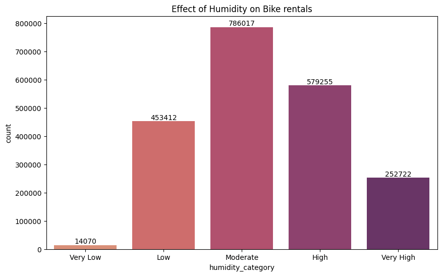

```python
# PLotting humidity Category with Total count of bike users.

humidity_data = data.groupby('humidity_category')['count'].sum().reset_index()

plt.figure(figsize=(10,6))

ax = sns.barplot(data=humidity_data, x='humidity_category', y='count', hue='humidity_category', palette='flare', errorbar=None)

for container in ax.containers:
  ax.bar_label(container, fmt="%.0f")

plt.title("Effect of Humidity on Bike rentals")
plt.show()
```

#### Insights:

1. Bike rentals are highest during moderate humidity conditions, indicating that users prefer comfortable atmospheric conditions for riding.
2. Rental demand decreases as humidity levels become very high, suggesting that excessively humid weather negatively affects bike usage.
3. Very low humidity conditions recorded the lowest rental activity, while low-to-high humidity ranges maintained comparatively stronger and more stable rental demand.

```python
data.head(10)
```

|  | datetime | season | holiday | workingday | weather | temp | atemp | humidity | windspeed | casual | registered | count | month | date | hour | year | dayofweek | temp_category | humidity_category |
| --- | --- | --- | --- | --- | --- | --- | --- | --- | --- | --- | --- | --- | --- | --- | --- | --- | --- | --- | --- |
| 0 | 2011-01-01 00:00:00 | 1 | 0 | 0 | 1 | 9.84 | 14.395 | 81 | 0.0000 | 3 | 13 | 16 | 1 | 1 | 0 | 2011 | Saturday | Very Cold | Very High |
| 1 | 2011-01-01 01:00:00 | 1 | 0 | 0 | 1 | 9.02 | 13.635 | 80 | 0.0000 | 8 | 32 | 40 | 1 | 1 | 1 | 2011 | Saturday | Very Cold | High |
| 2 | 2011-01-01 02:00:00 | 1 | 0 | 0 | 1 | 9.02 | 13.635 | 80 | 0.0000 | 5 | 27 | 32 | 1 | 1 | 2 | 2011 | Saturday | Very Cold | High |
| 3 | 2011-01-01 03:00:00 | 1 | 0 | 0 | 1 | 9.84 | 14.395 | 75 | 0.0000 | 3 | 10 | 13 | 1 | 1 | 3 | 2011 | Saturday | Very Cold | High |
| 4 | 2011-01-01 04:00:00 | 1 | 0 | 0 | 1 | 9.84 | 14.395 | 75 | 0.0000 | 0 | 1 | 1 | 1 | 1 | 4 | 2011 | Saturday | Very Cold | High |
| 5 | 2011-01-01 05:00:00 | 1 | 0 | 0 | 2 | 9.84 | 12.880 | 75 | 6.0032 | 0 | 1 | 1 | 1 | 1 | 5 | 2011 | Saturday | Very Cold | High |
| 6 | 2011-01-01 06:00:00 | 1 | 0 | 0 | 1 | 9.02 | 13.635 | 80 | 0.0000 | 2 | 0 | 2 | 1 | 1 | 6 | 2011 | Saturday | Very Cold | High |
| 7 | 2011-01-01 07:00:00 | 1 | 0 | 0 | 1 | 8.20 | 12.880 | 86 | 0.0000 | 1 | 2 | 3 | 1 | 1 | 7 | 2011 | Saturday | Very Cold | Very High |
| 8 | 2011-01-01 08:00:00 | 1 | 0 | 0 | 1 | 9.84 | 14.395 | 75 | 0.0000 | 1 | 7 | 8 | 1 | 1 | 8 | 2011 | Saturday | Very Cold | High |
| 9 | 2011-01-01 09:00:00 | 1 | 0 | 0 | 1 | 13.12 | 17.425 | 76 | 0.0000 | 8 | 6 | 14 | 1 | 1 | 9 | 2011 | Saturday | Cold | High |